# Week1 Code

xiliu

10/1/2017

*R is free, RStudio is free and R Markdown is free.*  
*Give thanks to John Chambers (create S language), Hadley Wickham and Yihui Xie.*

# 1 Installing R and R studio

## 1.1 Download and install R

- Go to https://www.r-project.org/
- Click on Download [CRAN](https://cran.r-project.org/mirrors.html)
- Choose the mirror closest to us in location: http://cran.stat.ucla.edu/
- Select the operation system
- Select the most recent version of R (R-3.4.1.pkg)
- Follow the installer in steps to install R

## 1.2 Download and install RStudio

- Go to http://www.rstudio.com
- Click on [RStudio Download](https://www.rstudio.com/products/rstudio/download/)
- Choose the first one, RStudio Deskto Open Source License, click on `DOWNLOAD`
- Choose the Installers for Supported Platforms and download the RStudio
- Follow the installer in steps to install R

*[Mac installation video reference](https://www.youtube.com/watch?v=d-u_7vdag-0)*  
*[Windows installation video reference](https://www.youtube.com/watch?v=9-RrkJQQYqY)*

# 2 Loading a package

The capabilities of R are extended through user-created `packages`. If you want to use the specific functions or datasets in certain packages, install these packages first. Then every time you open R(RStudio), require the corresponding packages before you run the functions in them.

```r
############          install packages   # only one time             ############
install.packages("knitr") # R Markdown package
install.packages("alr4") # Course datasets used in homework
install.packages("faraway") # Course datasets used in homework
############                      require packages                   ############
library(knitr)
library(alr4)
library(faraway)
```

# 3 R basics

## 3.1 Objects in R

- Vectors-*atomic* structure, which means components are all of the same type, or mode, namely numeric, complex, logical, character and raw.

```r
numeric.vector<-c(2017, 10, 4)
character.vector<-c("try","to","be","a","qualified","data","scientise")
```

- Array-*atomic* structure. As well as giving a vector structure a dim attribute, arrays can be constructed from vectors by the array function.  
  Matrix is 2*2 array, which is the most useful one in this class.

```r
matrix.example<-matrix(1:12, nrow = 3, ncol = 4)
matrix.example
```

```
##      [,1] [,2] [,3] [,4]
## [1,]    1    4    7   10
## [2,]    2    5    8   11
## [3,]    3    6    9   12
```

- Lists-*recursive* structure. These are ordered sequences of objects which individually can be of any mode.  
  An special case of list is `data.frame`, which requires all columns whould have the same length.

```r
list.example<-list(language=c("R","Matlab","Python","JAVA"),
                   OpenOrNot=c(TRUE,FALSE,TRUE), # this colume only has three elements.
                   RateByMe=c(9,7,10,8))
data.frame.example<-data.frame(language=c("R","Matlab","Python","JAVA"),
                               OpenOrNot=c("TRUE","FALSE","TRUE","Part"),
                               RateByMe=c(9,7,10,8)) # length of all columns is 4.
data.frame.example
```

```
##   language OpenOrNot RateByMe
## 1        R      TRUE        9
## 2   Matlab     FALSE        7
## 3   Python      TRUE       10
## 4     JAVA      Part        8
```

- Functions are the objects that form part of the R system along with similar user written functions.

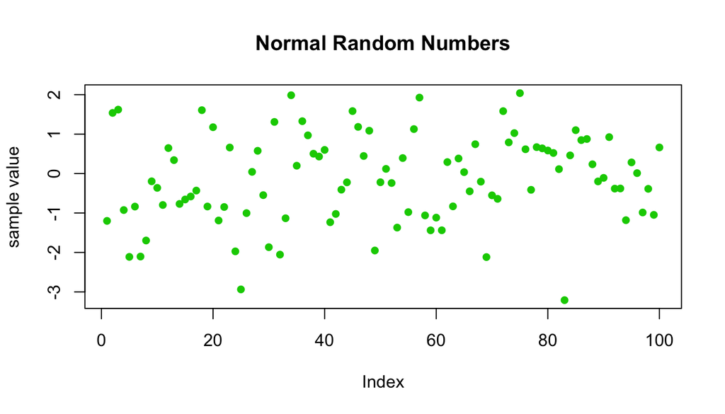

```r
set.seed(20171004)
plot(rnorm(100),ylab = "sample value",main="Normal Random Numbers",pch=16,col=3)
```

## 3.2 Indexing

```r
############              accessing elements from vector              ############
character.vector[2]
```

```
## [1] "to"
```

```r
# change character.vector[2] to "2"
character.vector[2]<-"2" # when you put " " around the number, it is a character now.
character.vector[c(2:5)] # the same with character.vector[c(2,3,4,5)]
```

```
## [1] "2"         "be"        "a"         "qualified"
```

```r
############             accessing variables from a data frame         ############
data.frame.example[2,3] # element in second raw, third column
```

```
## [1] 7
```

```r
data.frame.example[, 2] # get the second column
```

```
## [1] TRUE  FALSE TRUE  Part
## Levels: FALSE Part TRUE
```

```r
data.frame.example$OpenOrNot # in data.frame, each column has a name, get the vector by name.
```

```
## [1] TRUE  FALSE TRUE  Part
## Levels: FALSE Part TRUE
```

# 4 R markdown basics

More about R Markdown, please visit http://rmarkdown.rstudio.com/lesson-1.html.

## 4.1 Workflow

1. Open a new .Rmd file.
2. Write document(define the format, for example, make your homework contain a content).
3. Knit document to create report(For your homework, choose PDF document and you will get a PDF file alongside .Rmd).

## 4.2 Text and Code chunks

### 4.2.1 Basic Markdown language

### 4.2.2 Code chunks options